# R Notebook

Good Morning:

This is your daily COVID-19 report, sent on Thursday, December 24, 2020 at 7:04 AM (PST). Shown below is a current **draft** in continual development and error checking. Please feel free to reach out with suggestions or issues!

## USA Overall

> As of yesterday, there has been a total of 18,512,479 cases of COVID-19 in the USA. This is a change of 227,750 (1.25%) new cases since the day prior. The 7 day moving average is currently 2.135e+05 new cases which is a -1.14% change since the day prior and -3.36% change since the week prior. The immediate trend is heading downward. Based on the addition of yesterday’s data, there was not a recent (within 3 days) inflection point (days since last inflection point: 8 –> 2020-12-16).

#### 7-day moving average of new cases in the US (2020-01-21 to 2020-12-23)

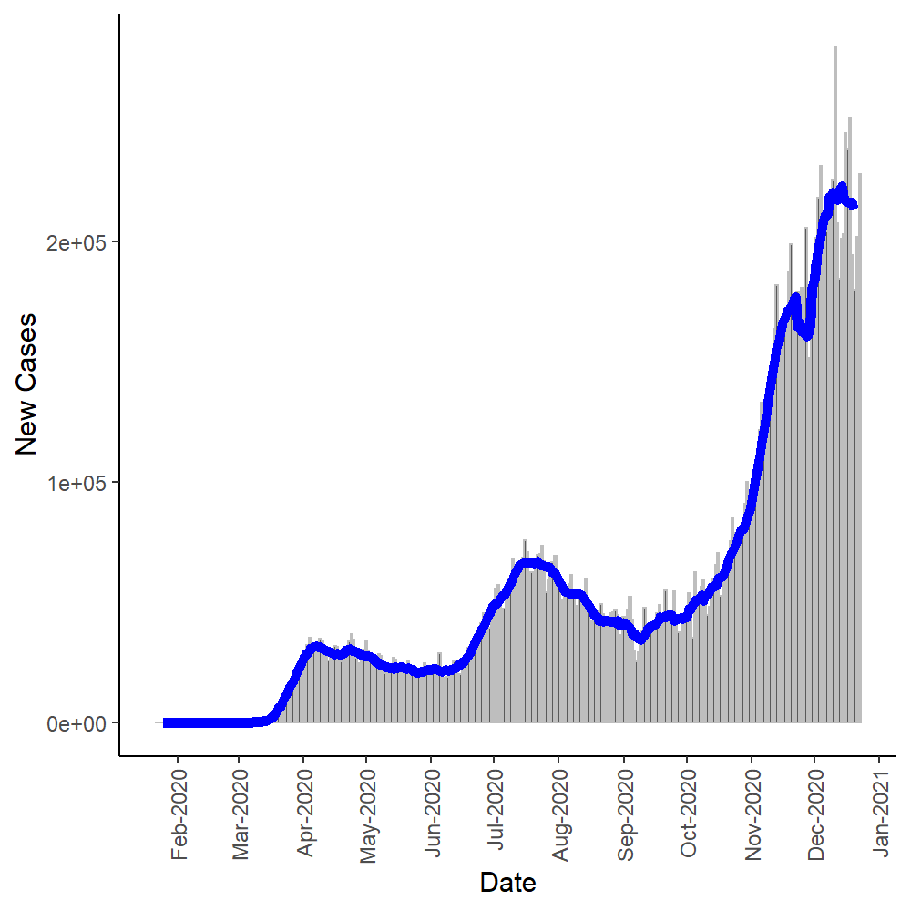

## Hospital Status

#### Summary

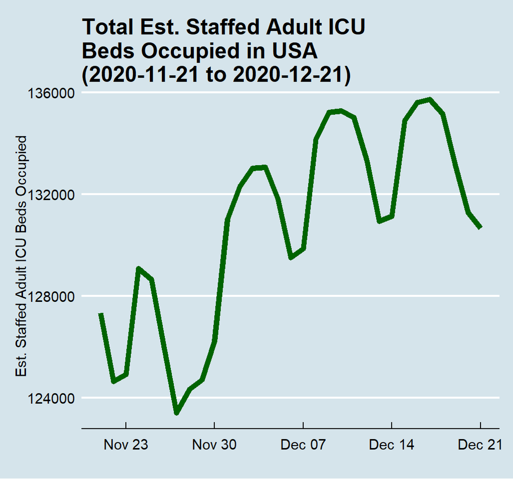

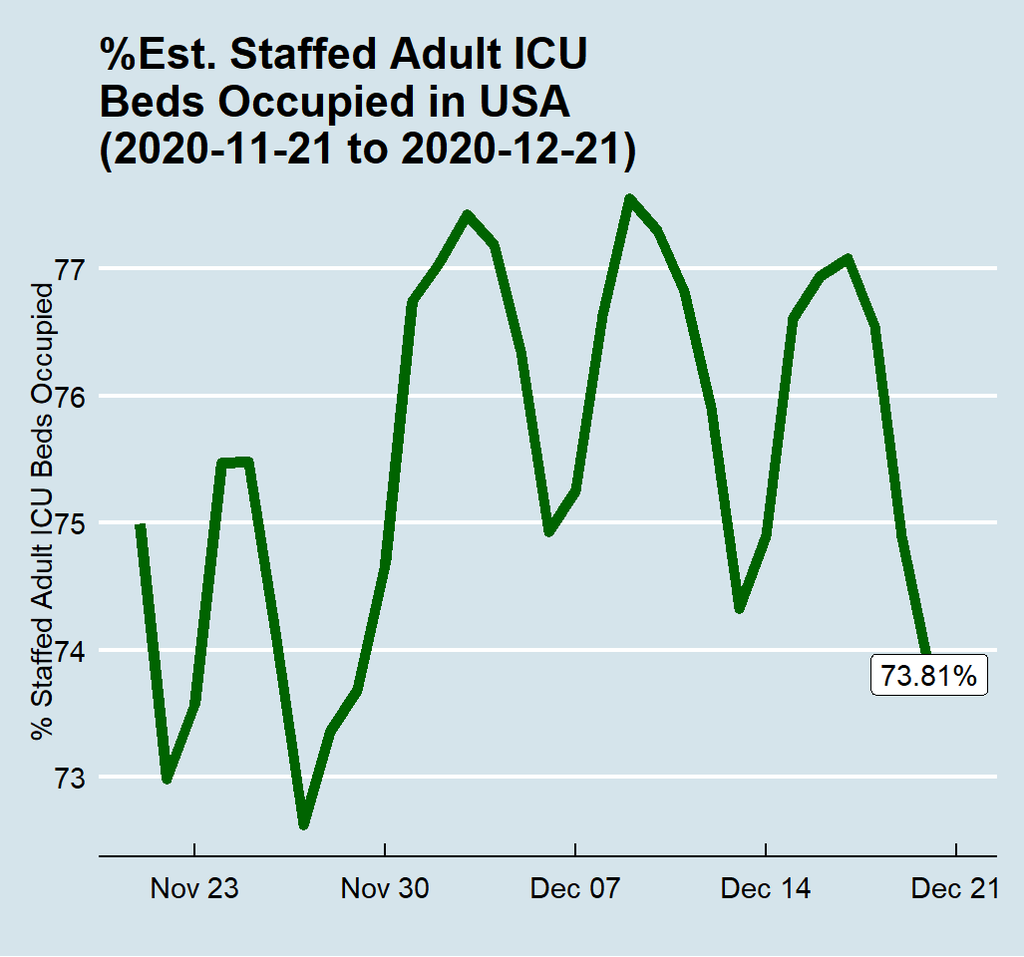

[figure not shown]

| Inpatient Hospital Usage | # States | percent |
| --- | --- | --- |
| extreme | 7 | 14% |
| high | 36 | 71% |
| low | 2 | 4% |
| moderate | 6 | 12% |

## Region by Region

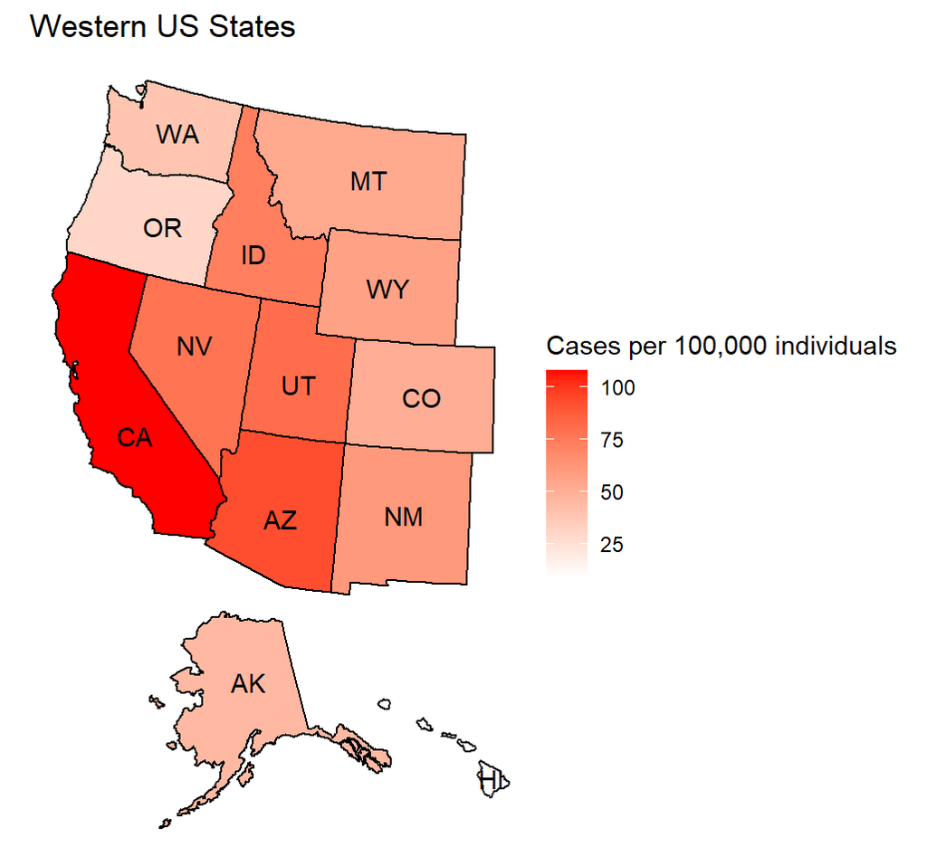

| State | Cases per 100,000 | Trend | ICU Stress | Inpatient Hospital Usage |
| --- | --- | --- | --- | --- |
| California | 108 | rising | extreme | extreme |
| Arizona | 93 | decreasing | extreme | extreme |
| Utah | 81 | decreasing | extreme | high |
| Nevada | 78 | decreasing | extreme | extreme |
| Idaho | 73 | decreasing | extreme | high |
| New Mexico | 61 | decreasing | extreme | high |
| Wyoming | 57 | decreasing | high | high |
| Montana | 53 | decreasing | extreme | moderate |
| Colorado | 51 | decreasing | extreme | high |
| Alaska | 45 | decreasing | extreme | moderate |
| Washington | 39 | rising | extreme | moderate |
| Oregon | 30 | decreasing | extreme | moderate |
| Hawaii | 9 | rising | extreme | low |

[figure not shown]

| State | Cases per 100,000 | Trend | ICU Stress | Inpatient Hospital Usage |
| --- | --- | --- | --- | --- |
| Tennessee | 121 | decreasing | extreme | high |
| Oklahoma | 88 | rising | extreme | high |
| Alabama | 85 | rising | extreme | high |
| Arkansas | 79 | rising | extreme | high |
| West Virginia | 70 | rising | extreme | high |
| Mississippi | 70 | decreasing | extreme | high |
| Georgia | 65 | rising | extreme | extreme |
| South Carolina | 65 | rising | extreme | high |
| Delaware | 65 | decreasing | extreme | high |
| North Carolina | 63 | rising | extreme | high |
| Kentucky | 61 | decreasing | extreme | high |
| Texas | 61 | decreasing | extreme | high |
| Florida | 56 | rising | extreme | high |
| Louisiana | 56 | rising | extreme | high |
| Virginia | 46 | rising | extreme | high |
| Maryland | 38 | decreasing | extreme | extreme |
| District of Columbia | 35 | decreasing | extreme | high |

[figure not shown]

| State | Cases per 100,000 | Trend | ICU Stress | Inpatient Hospital Usage |
| --- | --- | --- | --- | --- |
| Indiana | 77 | decreasing | extreme | high |
| Ohio | 74 | decreasing | extreme | high |
| Kansas | 73 | rising | extreme | high |
| South Dakota | 57 | decreasing | extreme | high |
| Nebraska | 55 | decreasing | extreme | high |
| Wisconsin | 55 | decreasing | high | high |
| Illinois | 53 | decreasing | extreme | high |
| Missouri | 53 | decreasing | extreme | high |
| Iowa | 52 | decreasing | extreme | moderate |
| Minnesota | 42 | decreasing | extreme | high |
| North Dakota | 38 | decreasing | extreme | high |
| Michigan | 37 | decreasing | extreme | high |

[figure not shown]

| State | Cases per 100,000 | Trend | ICU Stress | Inpatient Hospital Usage |
| --- | --- | --- | --- | --- |
| Rhode Island | 79 | decreasing | extreme | extreme |
| Pennsylvania | 69 | decreasing | extreme | extreme |
| Massachusetts | 67 | decreasing | extreme | high |
| New Hampshire | 55 | decreasing | high | high |
| New York | 53 | rising | extreme | high |
| Connecticut | 51 | decreasing | high | high |
| New Jersey | 48 | decreasing | extreme | high |
| Maine | 34 | rising | extreme | moderate |
| Vermont | 15 | decreasing | extreme | low |

Resources to check out:

- [See How All 50 States Are Reopening (and Closing Again)](https://www.nytimes.com/interactive/2020/us/states-reopen-map-coronavirus.html)
- [NYtimes Visualizations for Case Tracking in U.S.](https://www.nytimes.com/interactive/2020/us/coronavirus-us-cases.html)
- [Coronavirus Drug and Treatment Tracker](https://www.nytimes.com/interactive/2020/science/coronavirus-drugs-treatments.html)
- [Coronavirus Vaccine Tracker](https://www.nytimes.com/interactive/2020/science/coronavirus-vaccine-tracker.html)